# Visualising robotics market opportunities with a circular barplot

Edgar Brea

15/10/2020

This plot compares the market size and growth for top 7 global markets for robotics products and services. The data comes from a leading market research company with a focus on emerging technologies. The plot shows parent markets and corresponding segments.

A summary of the market data used for the plot (parent market level):

```r
kable(data_vis)
```

| market_name | number_of_segments | total_size_USDM | avg_growth_rate_YoY_pct |
| --- | --- | --- | --- |
| Global Agricultural Robots Market | 5 | 3974.95 | 45.84 |
| Global Collaborative Robots Market | 5 | 2146.10 | 64.30 |
| Global Industrial Robot Sensors Market | 9 | 8403.24 | 7.39 |
| Global Industrial Robot Vision Systems Market | 5 | 2391.75 | 10.10 |
| Global Professional Cleaning Robots Market | 6 | 105.93 | 58.05 |
| Global Robotics as a Service Market | 6 | 971.57 | 19.65 |
| Global Vision Guided Robotics Market | 6 | 7970.00 | 16.42 |

The plot was developed using R’s ggplot2 package, and it combines barplots and scatter plots arranged in a polar coordinate system. Below is the R code:

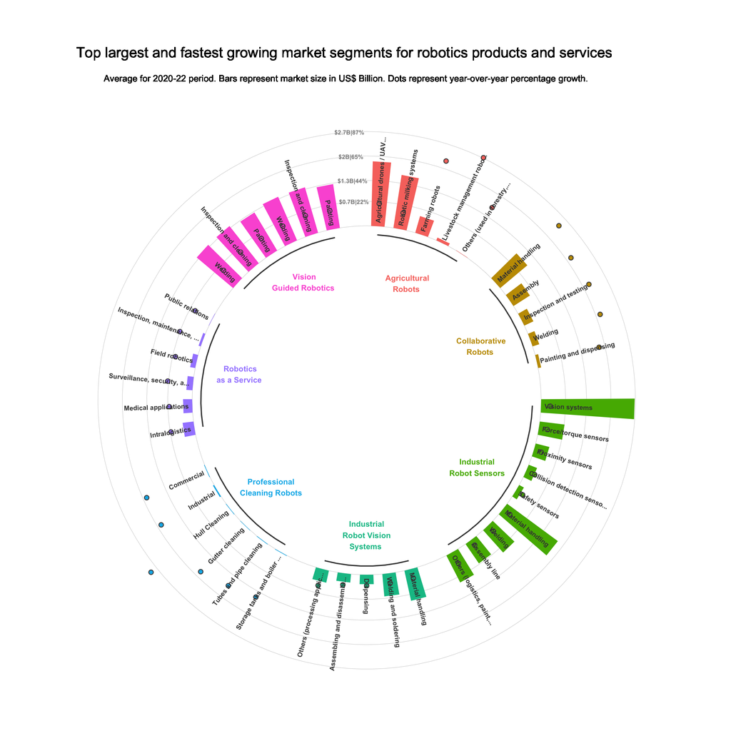

```r
ggplot(data_to_plot, aes(x = as.factor(id), y = mean_size, fill = market_name)) +
  geom_hline(yintercept = my_y_axis[4], colour = "grey", size = .15) +
  geom_hline(yintercept = my_y_axis[3], colour = "grey", size = .15) +
  geom_hline(yintercept = my_y_axis[2], colour = "grey", size = .15) +
  geom_hline(yintercept = my_y_axis[1], colour = "grey", size = .15) +
  geom_hline(yintercept = 0, colour = "grey", size = .15) +
  geom_bar(aes(x = as.factor(id), y = mean_size, fill = market_name), stat = "identity", width = 0.6) + #market size
  geom_point(aes(x = as.factor(id), y = mean_growth/30, fill = market_name), colour = "grey30", shape = 21, size = 2, stroke = .75) + #market growth
  scale_y_continuous(limits = c(0,10), sec.axis = sec_axis(trans = ~.*30)) +
  annotate("text", x = rep(max(data_to_plot$id),4), y = my_y_axis, label = paste0("$", as.character(my_y_axis), "B|", as.character(my_y_axis_sec), "%"), color="grey55", size = 2.5 , angle = 0, fontface="bold", hjust=0.5) +
  ylim(-5, 5) +
  theme_minimal() +
  theme(
    legend.position = "none",
    axis.text = element_blank(),
    axis.title = element_blank(),
    plot.title = element_text(hjust = 0.5),
    panel.grid = element_blank(),
    plot.margin = unit(c(-3,-3,-6,-3), "cm")) +
  coord_polar() +
  geom_text(data = label_data, aes(x = id, y = 0.1, label = market_segment_name, hjust = hjust), color = "grey25", fontface = "bold", size = 2.75, angle = label_data$angle, inherit.aes = F) + #market segment labels
  geom_segment(data=base_data, aes(x = start, y = -0.25, xend = end, yend = -.25), colour = "black", alpha=0.8, size=0.7 , inherit.aes = FALSE )  +
  geom_text(data = base_data, aes(x = title, y = -1.3, label = market_name, colour = market_name), size = 3.25, fontface = "bold", inherit.aes = F) + #market label
  geom_text(x = 0, y = 5, label = "Top largest and fastest growing market segments for robotics products and services", size = 6) + #title
  geom_text(x = 0, y = 4.25, label = "Average for 2020-22 period. Bars represent market size in US$ Billion. Dots represent year-over-year percentage growth.", size = 3.75) #subtitle
```

The plot help us see that, although the **Industrial Robot Sensors** and the **Vision Guided Robotics** markets are the largest markets currently, they are not expected to grow substantially in the coming years. Rather, we expect to see a significant growth in **Collaborative Robots**, **Professional Cleaning Robots** and **Agricultural Robots** markets in the coming years. This suggests a shift from the use of robotics in industrial settings characterised by repetitive tasks, to the **use of robotics in collaborative, commercial and outdoor environments characterised by unstructured, dynamic tasks**, a trend likely to be stimulated by **recent developments in machine learning and robot dexterity**.